# Week 8

Queueing Theory, Ch 17

Gareth Green

# Typical queueing model questions

- We use a number of formulas from the text derived from steady state
  - Derivations are long and detailed so not duplicate what is covered in the text
- Answer several questions
  1. Probability of *n* people in queue system or queue
  2. Probability wait in queue system or queue $\gt t$, pg 752-3
     - where $t$ is a specified time period to wait the business feels is reasonable
  3. Mean number of customers in queue system or queue
  4. Mean wait time in queue system or queue
- The utilization factor is important $\rho = \lambda /s \mu$, pg 735
  - $\rho$ is the the expected proportion servers are busy
    - Represents the the system’s service capacity $s\mu$, (servers * customer time/service)
    - that is being *utilized* by arriving customers at rate $\lambda$, customers needing service
- Related but determined separately is the cost of waiting and cost of additional servers
  - these determine the economic trade-off of hiring more servers to reduce wait time

# Problem set up

- Example #1, M/M/1/inf/inf/FCFS, aka M/M/1
  - Two customers arrive per hour
  - It takes 15 min (i.e. 4 per hour) to complete service.
- We will use two approaches:
  - first we will make calculations based on formulas derived in the text
    - this illustrates the power of using the **steady state** assumption
  - second we will use the `queueing` package to examine questions in more detail
    - will also allow us to answer questions in more complicated models
- Begin with estimating the probability of customers and wait times given one server
  - note *s* = 1 is the special case of an M/M/1 where $\rho = \lambda/\mu = 2/4 = 0.5$
  - you should expect your server to be busy (i.e. utilized) half of the time
  - must have $\rho < 1$ otherwise the queue will grow to infinity
    - i.e. more people than capacity

```r
# Set parameters
lam <- 2
mu <- 4
s <- 1 # One server case
rho <- lam/(s*mu)

# Probability of 0 people, see pg 751
p0 <- 1 - rho

# Let's look for up to 5 people
n <- 5

# Build a table of results, go to n + 1 so can see Pn when there are 0 customers
tab_1 <- as.data.frame(matrix(0, n + 1, 7))
```

# Code the calculations

- We’re not using any functions, just making calculations based on formula

```r
# Set a loop to make steady state calculations for each level of i customers in system
for (i in 0:n){
  # Probability of i people in queue system, see pg 751
  Pn <- p0*rho^i

  # Mean number of customers in queue system, see pg 751-2
  L <- lam/(mu - lam)

  # Mean wait time in queue system, by Little's Law pg 736
  W <- L/lam

  #Mean wait time in queue waiting for service, by Little's Law pg 736
  Wq <- W - 1/mu

  # Mean number of customers in queue, by Little's Law pg 736
  Lq <- lam * Wq

  # Combine in a table
  tab_1[i + 1, ] <- round(c(i, Pn, s, L, Lq, W*60, Wq*60), 3)
}

# Put header on table and name the header in the same line of code
colnames(tab_1) <- c_name <- c("Customers", "Pn", "s", "L", "Lq", "W (minutes)", "Wq (minutes)")
```

| Customers | Pn | s | L | Lq | W (minutes) | Wq (minutes) |
| --- | --- | --- | --- | --- | --- | --- |
| 0 | 0.500 | 1 | 1 | 0.5 | 30 | 15 |
| 1 | 0.250 | 1 | 1 | 0.5 | 30 | 15 |
| 2 | 0.125 | 1 | 1 | 0.5 | 30 | 15 |
| 3 | 0.062 | 1 | 1 | 0.5 | 30 | 15 |
| 4 | 0.031 | 1 | 1 | 0.5 | 30 | 15 |
| 5 | 0.016 | 1 | 1 | 0.5 | 30 | 15 |

- Recall what each of these variables represents?
  - Pn is the probability of n people in the system
- Why are the other variables constant?
  - because they are expected values in a steady state

# Can make similar calculations using the `queueing` package

- `queueing` is an impressive package
  - check the [documentation](https://www.rdocumentation.org/packages/queueing/versions/0.2.12)
- What was the main reason we were able to make easy calculations above??
- Now use the queueing package to make the same calculations
  - We can make own calculations easily for M/M/1 model
  - Gets much more complicated for other models so use `queueing` package
- For example, if $s = 1$, then $P_0 = 1 - \rho$
  - but for $s > 1$, $P_0$ is a massive equation, see top pg 754
- We can pull the output from each model run for different number of customers

```r
# create memory for a table of results, expand table
n <- 10
tab_q1 <- as.data.frame(matrix(0, n+1, 7))

# Set a loop to make steady state calculations for each level of i customers in system
for (i in 0:n){
  # Using "queueing" package
  q_mod1 <- NewInput.MM1(lam, mu, i)
  m1 <- QueueingModel.i_MM1(q_mod1)

  # Place results as a row in a table
    # Multiply wait by 60 minutes in an hour to convert time from hours to minutes
  tab_q1[i+1,] <- round(c(i, m1$Pn[i+1], s, m1$L, m1$Lq, m1$W*60, m1$Wq*60), 3)
}

# Add column names
colnames(tab_q1) <- c_name
```

# Model results

| Customers | Pn | s | L | Lq | W (minutes) | Wq (minutes) |
| --- | --- | --- | --- | --- | --- | --- |
| 0 | 0.500 | 1 | 1 | 0.5 | 30 | 15 |
| 1 | 0.250 | 1 | 1 | 0.5 | 30 | 15 |
| 2 | 0.125 | 1 | 1 | 0.5 | 30 | 15 |
| 3 | 0.063 | 1 | 1 | 0.5 | 30 | 15 |
| 4 | 0.031 | 1 | 1 | 0.5 | 30 | 15 |
| 5 | 0.016 | 1 | 1 | 0.5 | 30 | 15 |
| 6 | 0.008 | 1 | 1 | 0.5 | 30 | 15 |
| 7 | 0.004 | 1 | 1 | 0.5 | 30 | 15 |
| 8 | 0.002 | 1 | 1 | 0.5 | 30 | 15 |
| 9 | 0.001 | 1 | 1 | 0.5 | 30 | 15 |
| 10 | 0.000 | 1 | 1 | 0.5 | 30 | 15 |

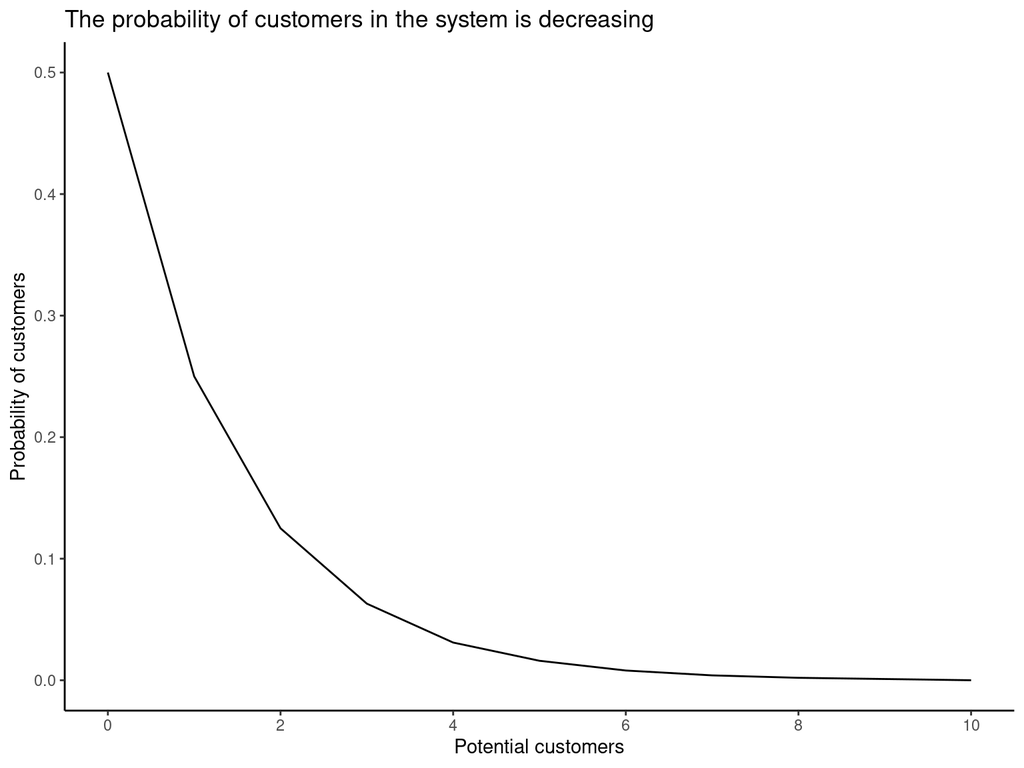

# Other output from queueing

- Important to pay attention to the definitions because there are many possibilities
- Can use queuing package to calculate other values too
  - Probability all servers are busy

```r
# Probability all servers are busy
B_erlang(s, lam/mu)
```

```
## [1] 0.3333333
```

- Probability to wait in queue because all servers are busy

```r
# Probability to wait in queue because all servers are busy
C_erlang(s, lam/mu)
```

```
## [1] 0.5
```

- C_erlang is higher because there is servers being busy and other customers in the queue
- These are different than $P_n$ which is probability of $n$ customers in the system
- Another way to get output from the model

```r
# Use the Report() function
Report(m1)
```

```
## The inputs of the M/M/1 model are:
## lambda: 2, mu: 4, n: 10
##
## The outputs of the M/M/1 model are:
##
## The probability (p0, p1, ..., pn) of the n = 10 clients in the system are:
## 0.5 0.25 0.125 0.0625 0.03125 0.015625 0.0078125 0.00390625 0.001953125 0.0009765625 0.0004882812
## The traffic intensity is: 0.5
## The server use is: 0.5
## The mean number of clients in the system is: 1
## The mean number of clients in the queue is: 0.5
## The mean number of clients in the server is: 0.5
## The mean time spend in the system is: 0.5
## The mean time spend in the queue is: 0.25
## The mean time spend in the server is: 0.25
## The mean time spend in the queue when there is queue is: 0.5
## The throughput is: 2
```

# Example #2, M/M/3/inf/inf/FCFS aka M/M/3

- A call center which has an arrival rate of 15 calls per hour
  - Each query take approximately 10 minutes ($\mu = 6$ per hour) to be resolved
  - Suppose there are 3 servers
- The utilization rate is $\rho = \lambda/(s*\mu) = 15/(3*6) = 0.83$
- **What are the system outcomes??**

```r
# Set up problem with criteria and 8 customers
n <- 8; lam = 15; mu = 6; s = 3

# Build a table of results
tab_q2 <- as.data.frame(matrix(0, n+1, 7))

# Loop to build table of results
for (i in 0:n){

  # Using "queueing" package
  q_mod2 <- NewInput.MMC(lambda = lam, mu = mu, c = s, n = n)
  m2 <- QueueingModel.i_MMC(q_mod2)

  # Place results as a row in a table
    # Multiply wait by 60 minutes in an hour to convert time from hours to minutes
  tab_q2[i+1,] <- round(c(i, m2$Pn[i + 1], m2$Inputs$c, m2$L, m2$Lq, m2$W*60, m2$Wq*60), 3)
}

# Add column names
colnames(tab_q2) <- c_name
```

# Model output

- Average 6 people in the system and 3.5 in the queue
  - Average 24 minutes in the system with 14 minutes waiting in the queue
  - 14 minutes is a long time to wait for a 10 minute service

| Customers | Pn | s | L | Lq | W (minutes) | Wq (minutes) |
| --- | --- | --- | --- | --- | --- | --- |
| 0 | 0.045 | 3 | 6.011 | 3.511 | 24.045 | 14.045 |
| 1 | 0.112 | 3 | 6.011 | 3.511 | 24.045 | 14.045 |
| 2 | 0.140 | 3 | 6.011 | 3.511 | 24.045 | 14.045 |
| 3 | 0.117 | 3 | 6.011 | 3.511 | 24.045 | 14.045 |
| 4 | 0.098 | 3 | 6.011 | 3.511 | 24.045 | 14.045 |
| 5 | 0.081 | 3 | 6.011 | 3.511 | 24.045 | 14.045 |

<sup>a</sup> Probability customers will wait in the queue 0.702  
<sup>a</sup> Probability all servers are busy is 0.282

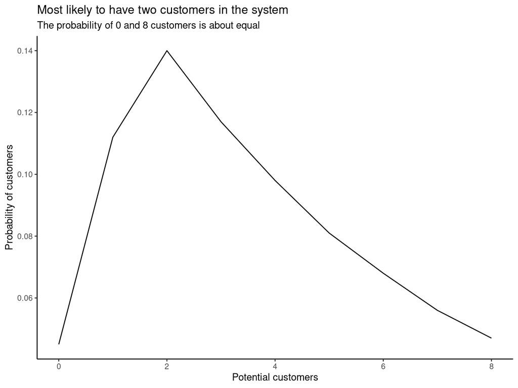

# In M/M/C, how do variables change with Servers

```r
# Number of cutomers, Initial servers
n <- 8; int <- 3

# Build a table of results
tab_q3 <- as.data.frame(matrix(0, n+1-int, 7))

# Loop to build table of results
for (s in int:n){

  # Using "queueing" package
  q_mod3 <- NewInput.MMC(lambda = lam, mu = mu, c = s, n = n)
  m3 <- QueueingModel.i_MMC(q_mod3)

  # Place results as a row in a table
    # Multiply wait by 60 minutes in an hour to convert time from hours to minutes
  tab_q3[s+1-int,] <- round(c(s, m3$L, m3$Lq, m3$W*60, m3$Wq*60, B_erlang(s, lam/mu), C_erlang(s, lam/mu)), 3)
}

# Add column names
colnames(tab_q3) <- c("Servers", "L", "Lq", "W (minutes)", "Wq (minutes)", "B_erlang", "C_erlang")
```

# Model results

- Wow, one more server reduces the wait time to just over 2 minutes
  - and reduce the number of people waiting in the queue by 3
  - getting 5 servers (2 more) reduces wait time to just over 30 seconds

| Servers | L | Lq | W (minutes) | Wq (minutes) | B_erlang | C_erlang |
| --- | --- | --- | --- | --- | --- | --- |
| 3 | 6.011 | 3.511 | 24.045 | 14.045 | 0.282 | 0.702 |
| 4 | 3.033 | 0.533 | 12.132 | 2.132 | 0.150 | 0.320 |
| 5 | 2.630 | 0.130 | 10.521 | 0.521 | 0.070 | 0.130 |
| 6 | 2.534 | 0.034 | 10.136 | 0.136 | 0.028 | 0.047 |
| 7 | 2.509 | 0.009 | 10.034 | 0.034 | 0.010 | 0.015 |
| 8 | 2.502 | 0.002 | 10.008 | 0.008 | 0.003 | 0.005 |

- Easy to see why companies want to automate queues
  - can reduce queue time dramatically with low cost of automation
  - at least keep customers engaged as part of the queue process at low cost

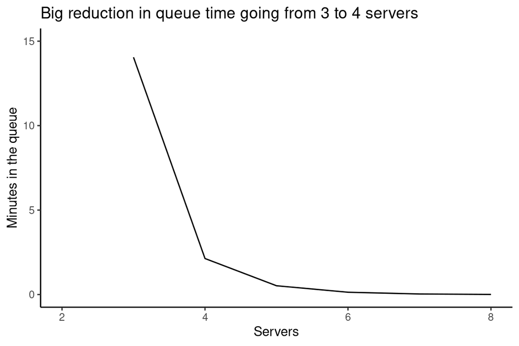

# Work through a complete question

Several students had a start up idea of helping people with their software by using a software package that allows them to easily control someones computer remotely with their permission. Softie.com’s goal is to deliver personal service over the internet. They believe there is a niche market for people that want to see and talk to actual people rather than bots. Softie.com is a student team trying to figure out how to launch and has the following parameters:

- 2 server call center (to get started)
- 9 inquiries per hour (based on an estimate from industry data)
- Each query take approximately 12 minutes (5 per hour) to be resolved
- What is the utilization rate?
  - The utilization rate indicates the proportion a system’s servers are in use
  - $\rho = \lambda/(s*\mu) = 9/(2*5) = 0.9$
  - They are at a high utilization so they are likely to have some long wait times in the queue
  - It may be difficult to make it in a niche market with a goal of quality and long wait times
  - **Set up the problem in R**

# Set up the problem

```r
# Set up problem with criteria and 10 customers
lam = 9; mu = 5; s = 2; n <- 20;

# Using "queueing" package
soft_mod <- NewInput.MMC(lambda = lam, mu = mu, c = s, n = n)
sm <- QueueingModel.i_MMC(soft_mod)
```

- Though the probabilities are low, they drop off slowly
  - The graph is over 20 customers
  - This indicates long queue wait times

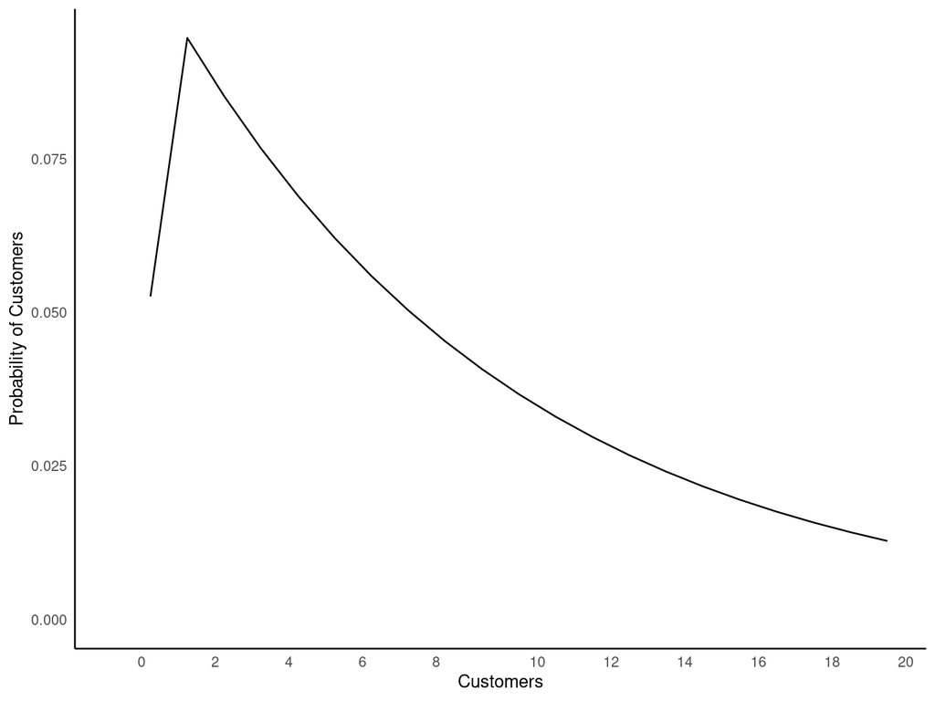

# Get full model results

- Any way you look at it these numbers are bad!
  - W = 63 minutes
  - Wq = 51 minutes
- People won’t wait that long for service even if it is amazing
- The problem with hiring more servers is that the utilization rate drops
- Servers sit idle due to randomness of arriving customers
- Idle servers is expensive
- you can see $\rho$ drops off slowly

| Servers | rho |
| --- | --- |
| 2 | 0.90 |
| 3 | 0.60 |
| 4 | 0.45 |
| 5 | 0.36 |
| 6 | 0.30 |
| 7 | 0.26 |
| 8 | 0.22 |

```
## The inputs of the model M/M/c are:
## lambda: 9, mu: 5, c: 2, n: 20, method: Exact
##
## The outputs of the model M/M/c are:
##
## The probability (p0, p1, ..., pn) of the n = 20 clients in the system are:
## 0.05263158 0.09473684 0.08526316 0.07673684 0.06906316 0.06215684 0.05594116 0.05034704 0.04531234 0.0407811 0.03670299 0.03303269 0.02972942 0.02675648 0.02408083 0.02167275 0.01950548 0.01755493 0.01579944 0.01421949 0.01279754
## The traffic intensity is: 1.8
## The server use is: 0.9
## The mean number of clients in the system is: 9.47368421052632
## The mean number of clients in the queue is: 7.67368421052632
## The mean number of clients in the server is: 1.8
## The mean time spend in the system is: 1.05263157894737
## The mean time spend in the queue is: 0.852631578947369
## The mean time spend in the server is: 0.2
## The mean time spend in the queue when there is queue is: 1
## The throughput is: 9
```

# What about more servers??

- The student team is reluctant to hire more servers
  - don’t want servers sitting idle
  - they hatch an idea that idle servers can provide additional services
- **What is the probability currently with two servers that one could work on an optional service?**
  - That would be $\sum_0^1 P_i = P_0 + P_1$ = 0.147
  - That is pretty low, how much do think it would increase with another server?
- **What is the probability of time to work on other services if hire a third server?**

```r
# Set up problem with criteria and 20 customers
lam = 9; mu = 5; s = 3; n <- 20;

# Using "queueing" package
soft_mod <- NewInput.MMC(lambda = lam, mu = mu, c = s, n = n)
sm <- QueueingModel.i_MMC(soft_mod)
```

- That would be $\sum_0^2 P_i = P_0 + P_1 + P_2$ = 0.645

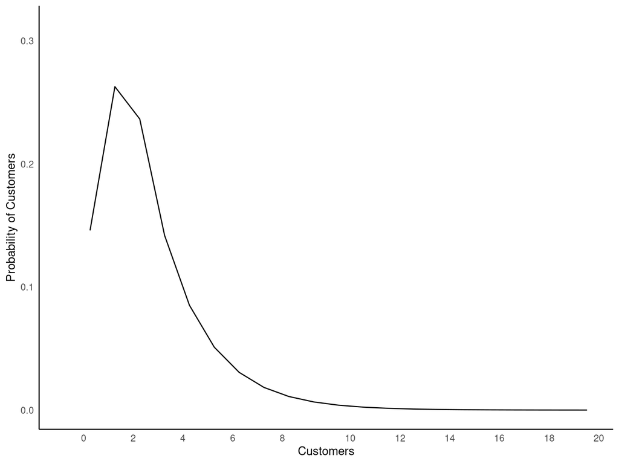

# Get full model results

- This is substantially better, servers could have time for an additional product!
  - W = 16 minutes
  - Wq = 4 minutes
- What are other results?
  - you can see the Pn drops off quickly
- Though the physical numbers look good, what does this trade-off come down to?
  - **The cost of servers vs the cost of waiting**

```
## The inputs of the model M/M/c are:
## lambda: 9, mu: 5, c: 3, n: 20, method: Exact
##
## The outputs of the model M/M/c are:
##
## The probability (p0, p1, ..., pn) of the n = 20 clients in the system are:
## 0.1459854 0.2627737 0.2364964 0.1418978 0.08513869 0.05108321 0.03064993 0.01838996 0.01103397 0.006620384 0.003972231 0.002383338 0.001430003 0.0008580018 0.0005148011 0.0003088806 0.0001853284 0.000111197 6.671822e-05 4.003093e-05 2.401856e-05
## The traffic intensity is: 1.8
## The server use is: 0.6
## The mean number of clients in the system is: 2.33211678832117
## The mean number of clients in the queue is: 0.532116788321168
## The mean number of clients in the server is: 1.8
## The mean time spend in the system is: 0.259124087591241
## The mean time spend in the queue is: 0.0591240875912409
## The mean time spend in the server is: 0.2
## The mean time spend in the queue when there is queue is: 0.166666666666667
## The throughput is: 9
```

# How does hiring servers impact time in the queue

- Suppose Softie determines they can charge more if they can get the queue time to less than 30 seconds
  - How many servers will they need to hire?
- Here we will loop over the number of servers

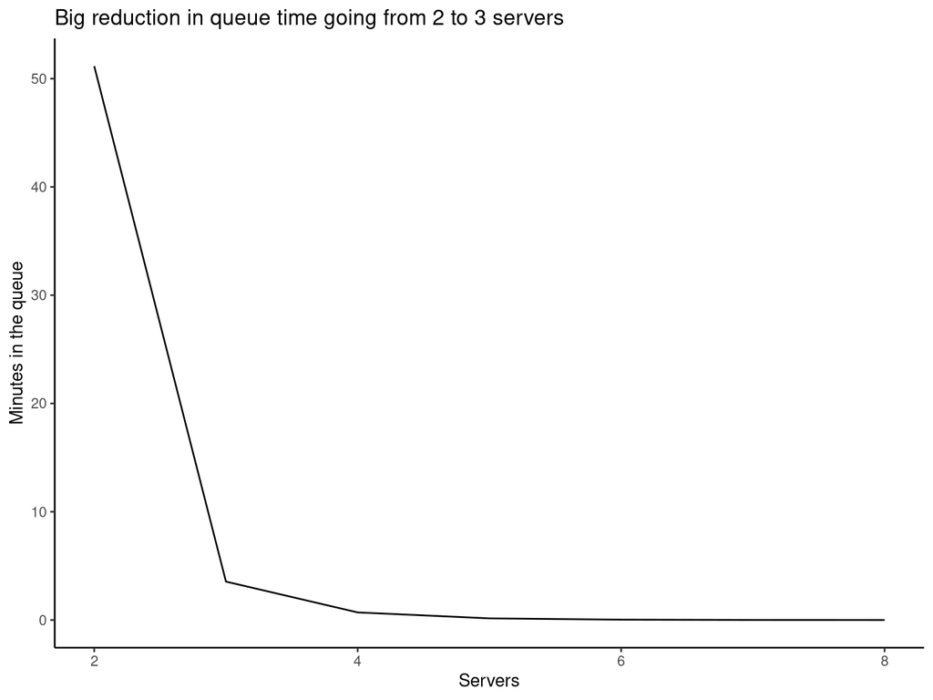

```r
# Set up problem with initial criteria and 20 customers
lam = 9; mu = 5; s = 2; n <- 8; int <- 2

# Build a table of results
tab_smc <- as.data.frame(matrix(0, n+1-int, 7))

# Loop to build table of results
for (s in int:n){

  # Using "queueing" package
  sm_c <- NewInput.MMC(lambda = lam, mu = mu, c = s, n = n)
  smc <- QueueingModel.i_MMC(sm_c)

  # Place results as a row in a table
    # Multiply wait by 60 minutes in an hour to convert time from hours to minutes
  tab_smc[s+1-int,] <- round(c(s, smc$L, smc$Lq, smc$W*60, smc$Wq*60, B_erlang(s, lam/mu), C_erlang(s, lam/mu)), 3)
}

# Add column names
colnames(tab_smc) <- c("Servers", "L", "Lq", "W (minutes)", "Wq (minutes)", "B_erlang", "C_erlang")
```

# Numerical results show…

| Servers | L | Lq | W (minutes) | Wq (minutes) | B_erlang | C_erlang |
| --- | --- | --- | --- | --- | --- | --- |
| 2 | 9.474 | 7.674 | 63.158 | 51.158 | 0.367 | 0.853 |
| 3 | 2.332 | 0.532 | 15.547 | 3.547 | 0.180 | 0.355 |
| 4 | 1.905 | 0.105 | 12.701 | 0.701 | 0.075 | 0.129 |
| 5 | 1.823 | 0.023 | 12.152 | 0.152 | 0.026 | 0.040 |
| 6 | 1.805 | 0.005 | 12.032 | 0.032 | 0.008 | 0.011 |
| 7 | 1.801 | 0.001 | 12.006 | 0.006 | 0.002 | 0.003 |
| 8 | 1.800 | 0.000 | 12.001 | 0.001 | 0.000 | 0.001 |

# What if scenarios

Assume Softie.com purchased 2 more servers for a total of 4. But now Softie.com’s incoming business doubles. How many servers will they need more to maintain a less-than one-minute queue time?

[figure not shown]

```r
# Set up problem with initial criteria and 20 customers
lam = 9 * 2; mu = 5 ; s = 2; n <- 10; int <- 4

# Build a table of results
tab_smc <- as.data.frame(matrix(0, n+1-int, 7))

# Loop to build table of results
for (s in int:n){

  # Using "queueing" package
  sm_c <- NewInput.MMC(lambda = lam, mu = mu, c = s, n = n)
  smc <- QueueingModel.i_MMC(sm_c)

  # Place results as a row in a table
    # Multiply wait by 60 minutes in an hour to convert time from hours to minutes
  tab_smc[s+1-int,] <- round(c(s, smc$L, smc$Lq, smc$W*60, smc$Wq*60, B_erlang(s, lam/mu), C_erlang(s, lam/mu)), 3)
}

# Add column names
colnames(tab_smc) <- c("Servers", "L", "Lq", "W (minutes)", "Wq (minutes)", "B_erlang", "C_erlang")
```

# Numerical results show…

| Servers | L | Lq | W (minutes) | Wq (minutes) | B_erlang | C_erlang |
| --- | --- | --- | --- | --- | --- | --- |
| 4 | 10.690 | 7.090 | 35.633 | 23.633 | 0.271 | 0.788 |
| 5 | 4.655 | 1.055 | 15.518 | 3.518 | 0.163 | 0.410 |
| 6 | 3.895 | 0.295 | 12.983 | 0.983 | 0.089 | 0.197 |
| 7 | 3.691 | 0.091 | 12.304 | 0.304 | 0.044 | 0.086 |
| 8 | 3.628 | 0.028 | 12.094 | 0.094 | 0.019 | 0.035 |
| 9 | 3.608 | 0.008 | 12.028 | 0.028 | 0.008 | 0.013 |
| 10 | 3.602 | 0.002 | 12.008 | 0.008 | 0.003 | 0.004 |

- Going from 4 to 5 is huge, but need to go to 6 servers to be less than 1 minute wait
  - 5 servers still has a 3.5 minute wait
    - similar as going from 2 to 3 servers before
  - 6 servers has less than a 1 minute wait
    - before going from 3 to 4 had a 45 second wait
- Their business doubles but they only need to increase their servers by 50% to maintain a similar level of wait time in the queue
  - of course this is mean time
  - if we did a simulation we would see that some wait times are substantially larger and some substantially smaller
    - we will look at this in the next module
    - but Poisson is asymmetric to to you expect there to be more long waits or short waits?
    - this is a case where the mean may not be a good measure

# What if have cost data

- What if we knew the cost of lost customers and servers??
  - Still not an optimization problem like in earlier chapaters
  - But we can find the optimal number of servers
- **Problem set up**, same as before
  - A call center which has an arrival rate of 18 queries per hour
  - Each query take approximately 12 minutes (5 per hour) to be resolved
  - What is the cost minimizing number of servers if:
    - A server costs $15/hour
    - The firm loses $40 per lost customer
    - Cusomers will leave if the wait is more than 30 seconds

# Code the problem set up

- Similar to other queueing theory problems, but add costs

```r
# Set up problem with initial criteria and 10 customers
lam = 18; mu = 5 ; s = 2; n <- 10

# Minimum number of servers so queue not grow to infinity, ceiling rounds up to next integer
int <- ceiling(lam/mu)

# Profit per customer
pi <- 40

# Cost per server per hour
cost <- 15

# Build a table of results
tab_smc <- as.data.frame(matrix(0, n+1-int, 8))
```

- Note the time threshold of 30 seconds (0.5 minutes) for losing customers

```r
# Loop to build table of results
for (s in int:n){

  # Using "queueing" package
  sm_c <- NewInput.MMC(lambda = lam, mu = mu, c = s, n = n)
  smc <- QueueingModel.i_MMC(sm_c)

  # Cost of lost customers
  lp <- ifelse(smc$Wq*60 > 0.5, smc$Lq * pi, 0)
  # Cost of servers
  sc <- s*cost
  # Total cost
  tc <- sc + lp

  # Place results as a row in a table
    # Multiply wait by 60 minutes in an hour to convert time from hours to minutes
  tab_smc[s+1-int,] <- round(c(s, smc$L, smc$Lq, smc$W*60, smc$Wq*60, lp, sc, tc), 2)
}
```

# Results

| Servers | L | Lq | W (minutes) | Wq (minutes) | Lost Profit | Server Cost | Total Cost |
| --- | --- | --- | --- | --- | --- | --- | --- |
| 4 | 10.69 | 7.09 | 35.63 | 23.63 | 283.59 | 60 | 343.59 |
| 5 | 4.66 | 1.06 | 15.52 | 3.52 | 42.21 | 75 | 117.21 |
| 6 | 3.89 | 0.29 | 12.98 | 0.98 | 11.79 | 90 | 101.79 |
| 7 | 3.69 | 0.09 | 12.30 | 0.30 | 0.00 | 105 | 105.00 |
| 8 | 3.63 | 0.03 | 12.09 | 0.09 | 0.00 | 120 | 120.00 |
| 9 | 3.61 | 0.01 | 12.03 | 0.03 | 0.00 | 135 | 135.00 |
| 10 | 3.60 | 0.00 | 12.01 | 0.01 | 0.00 | 150 | 150.00 |

- Look for minimum TC
- 6 servers gives the minimum cost of trading off between servers and lost customers
  - Cost of lost customers decreases as cost of servers increases
  - Note the cost of lost customers is still positive from 6 to 7 servers
    - inidicates it is optimal to lose some customers rather than hire additional servers
    - this is based on the probability of needing 7 servers vs the cost of hiring an aditional server
- Does anyone remember why we are using this calculated approach?

# Why use the numerical approach?

- This looks like a basic calculus problem
  - unconstrained minimization
  - just take the derivative of total cost with respect to *s*, right?
  - the function is complicated when $s > 1$
- Total cost = lost profit + server cost
  - $TC = L_q * \pi + s * cost$, which looks easy enough
  - $L_q$ = ${P_0(\lambda/\mu)^s\rho}\over{s!(1 - \rho)^2}$ = ${P_0(\lambda/\mu)^s\lambda/(s\mu)}\over{s!(1 - \lambda/(s\mu))^2}$
  - what is wrong with taking a derivative of this with respect to $s$?
  - factorials are discontinuous so a derivative doesn’t make sense
  - Also, the equation for $P_0$ is ridiculous, top pg 754

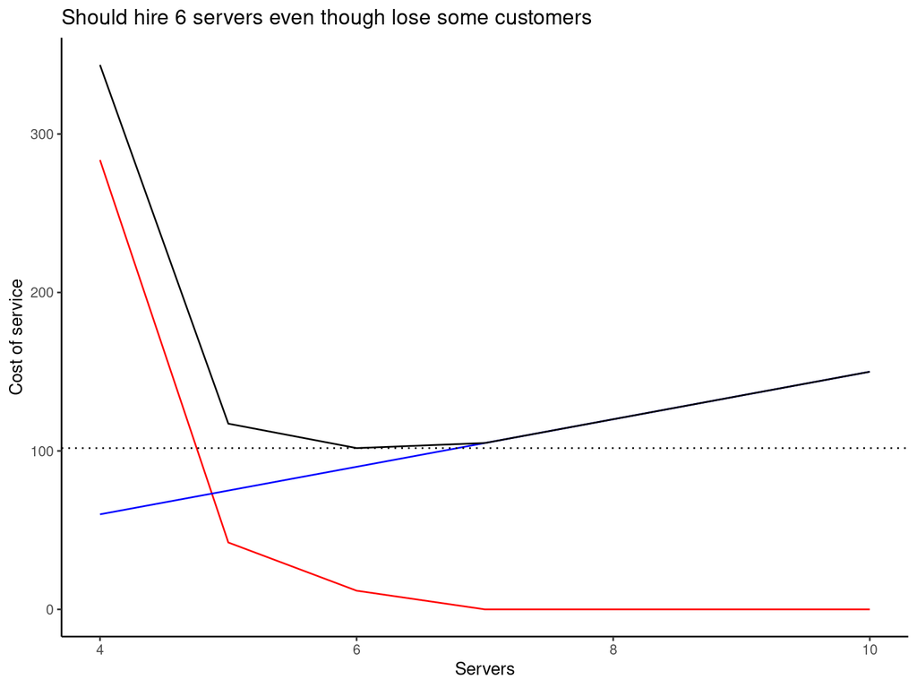

# Wrap up

- Queues are everywhere so are important to analyze and understand
  - We barely scratched the surface of Queueing Theory
  - Many online resources and [calculators](http://erlang.chwyean.com/erlang/erlangB.html)
  - Work through the `queueing` package if you want to learn more
- Can be very complex, we have only studied simple systems to understand the basics
  - Could easily spend a quarter just studying Queueing Theory
- We focused on using the steady state assumption and Little’s Law
  - This gave us good mean times to work with
  - Next week we will look at simulations to see how these variables vary around the mean values